# BMIN 503 Final Project

Caroline Joyce

12/12/2018

# Overview

Average MMR vaccination coverage rates in kindergartners was visualized in the years before and after passage of California Senate Bill 277.

# Introduction

The goal of my final project is to visually show the change in childhood vaccine medical exemption rates in California after legislation eliminating personal belief exemptions was enacted. The elimination of personal belief exemptions aimed to cut down on the number of unvaccinated children within schools, however, recent data is showing that these numbers may have solely transferred to medical exemptions. California is unique in making publically available all school-level kindergarten vaccination rates. This project will visually show the impact this law had upon medical exemption rates. In response to a number of infectious disease outbreaks, California has enacted two major vaccination policy changes in the last five years. First, in 2012, AB 2109 told schools that receive federal funding (both public and private) that they could not unconditionally admit children who were unvaccinated or did not have vaccine exemptions. Subsequently, in (2015) SB 277 was passed, eliminating personal belief exemptions (PBEs) for children entering schools. Due to this change, parents hoping to exempt their child from the standard vaccination schedule needed a signed note from a physician in order for their child to be enrolled in school. While the goal of this law was to cut down on the number of children that were un- and under-vaccinated, recent work has shown that their exemptions may have just been switched from PBEs to medical exemptions. Rates of coverage of the measles, mumps, and rubella (MMR) vaccine are particularly interesting to be studied, as there have been a number of measles outbreaks in California in the last ten years. This is not surprising, as the World Health Organization (WHO) shows that for herd immunity to be reached and the disease unable to spread, over 93% of the population must be vaccinated. In theory, the passage of SB 277 should have raised MMR vaccination rates to closer to the herd immunity rate. The goal of this project is to show any changes in MMR vaccination rates that came after this law was enacted in order to inform future policy decisions. This problem is interdisciplinary as it hits upon the intersection of legal policy and infectious disease. Additionally, it is uniquely ready to be studied as California is one of the few states that makes school-level vaccination rates public. I met with John Holmes to discuss publicly available state databases to compare the California data to, and he recommended that I look at nationally collected data, as finding state level data is quite rare. I met with Alison Buttenheim, and we spoke about how seeing the change in vaccination rates is important. The law was passed with the hope that childhood vaccination rates overall would increase, but it is entirely possible that this has not happened to the extent needed for herd immunization. I also met with Sherrie to discuss the best way to map these data.

# Methods

```r
library(tidyverse)
library(plyr)
library(dplyr)
library(choroplethr)
library(choroplethrMaps)
library(sf)
library(tidycensus)
library(leaflet)
library(ape)
library(spdep)
library(RColorBrewer)
setwd("~/Documents/BMIN 503")

twelve <- read.csv("2012-13CAKindergartenData.csv")
sixteen <- read.csv("2016-17KindergartenData.csv")


#Variables in the 2012 database were renamed

#rename variables
twelve <- dplyr::rename(twelve, School.Code = X2012.2013.IMMUNIZATION.STATUS.OF.KINDERGARTEN.STUDENTS..CALIFORNIA, county = X, Public.Private = X.1, district = X.2, city = X.3, school.name = X.4, enrollment = X.5, UTDnum = X.6, UTDpercent = X.7, conditionalnum = X.8, conditionalperc = X.9, PMEnum = X.10, PMEperc = X.11, PBEnum = X.12, PBEperc = X.13, DTPnum = X.14, DTPperc = X.15, Polionum = X.16, Polioperc = X.17, MMRnum = X.18, MMRperc = X.19, HEPBnum = X.20, HEPBperc = X.21, VARInum = X.22, VARIperc = X.23)

#empty rows were dropped
twelve <- twelve[-c(1, 2, 3, 4), ]


#approppriate columns were made numeric
twelve[7:26] <- lapply(twelve[7:26], function(x) as.numeric(as.character(x)))
str(twelve)
```

```
## 'data.frame':    7657 obs. of  26 variables:
##  $ School.Code    : Factor w/ 7659 levels "","    that the physical condition of the student or medical circumstances relating to the student are such that i"| __truncated__,..: 964 176 958 955 956 957 959 960 961 962 ...
##  $ county         : Factor w/ 60 levels "","ALAMEDA","ALPINE",..: 2 2 2 2 2 2 2 2 2 2 ...
##  $ Public.Private : Factor w/ 4 levels "","PRIVATE","PUBLIC",..: 3 3 3 3 3 3 3 3 3 3 ...
##  $ district       : Factor w/ 840 levels "","ABC UNIFIED",..: 744 684 649 649 649 649 649 649 649 649 ...
##  $ city           : Factor w/ 937 levels "","\"AVALON, CATALINA ISL\"",..: 821 453 730 731 731 731 731 731 731 731 ...
##  $ school.name    : Factor w/ 6628 levels "","'A CHILD'S PLACE' GROWTH AND DEVELOPMENT CENTER",..: 5781 3168 1349 372 1121 1199 1382 2193 2414 2455 ...
##  $ enrollment     : num  36 120 82 86 111 112 86 84 118 84 ...
##  $ UTDnum         : num  30 112 75 82 110 99 76 74 116 84 ...
##  $ UTDpercent     : num  83 93 91 95 99 88 88 88 98 100 ...
##  $ conditionalnum : num  0 3 7 3 1 13 10 7 2 0 ...
##  $ conditionalperc: num  0 3 9 3 1 12 12 8 2 0 ...
##  $ PMEnum         : num  0 0 0 1 0 0 0 0 0 0 ...
##  $ PMEperc        : num  0 0 0 1 0 0 0 0 0 0 ...
##  $ PBEnum         : num  6 5 0 0 0 0 0 3 0 0 ...
##  $ PBEperc        : num  17 4 0 0 0 0 0 4 0 0 ...
##  $ DTPnum         : num  30 112 79 84 110 105 78 76 117 84 ...
##  $ DTPperc        : num  83 93 96 98 99 94 91 90 99 100 ...
##  $ Polionum       : num  30 114 78 85 111 106 78 76 117 84 ...
##  $ Polioperc      : num  83 95 95 99 100 95 91 90 99 100 ...
##  $ MMRnum         : num  30 115 78 83 111 104 80 74 117 84 ...
##  $ MMRperc        : num  83 96 95 97 100 93 93 88 99 100 ...
##  $ HEPBnum        : num  30 114 78 85 111 108 79 78 118 84 ...
##  $ HEPBperc       : num  83 95 95 99 100 96 92 93 100 100 ...
##  $ VARInum        : num  30 114 80 85 111 110 81 78 117 84 ...
##  $ VARIperc       : num  83 95 98 99 100 98 94 93 99 100 ...
##  $ X.24           : num  NA NA NA NA NA NA NA NA NA NA ...
```

```r
#Variables of interest were averaged and grouped by county
twelve.group <- twelve %>% group_by(county) %>%  summarise_at(vars(enrollment:VARIperc), mean, na.rm = TRUE)

str(twelve.group)
```

```
## Classes 'tbl_df', 'tbl' and 'data.frame':    59 obs. of  20 variables:
##  $ county         : Factor w/ 60 levels "","ALAMEDA","ALPINE",..: 1 2 3 4 5 6 7 8 10 11 ...
##  $ enrollment     : num  NaN 64.1 19 47 53.6 ...
##  $ UTDnum         : num  NaN 55.9 16 42.5 47.3 ...
##  $ UTDpercent     : num  NaN 85.8 84 90.7 84.9 ...
##  $ conditionalnum : num  NaN 7.05 1 0.833 3.163 ...
##  $ conditionalperc: num  NaN 12.15 5 1.5 7.98 ...
##  $ PMEnum         : num  NaN 0.0631 0 0 0.0816 ...
##  $ PMEperc        : num  NaN 0.113 0 0 0.122 ...
##  $ PBEnum         : num  NaN 1.02 2 3.67 3.04 ...
##  $ PBEperc        : num  NaN 1.94 11 7.67 6.98 ...
##  $ DTPnum         : num  NaN 58 16 42.7 48.4 ...
##  $ DTPperc        : num  NaN 89.9 84 90.8 87.4 ...
##  $ Polionum       : num  NaN 57.9 16 42.7 48.2 ...
##  $ Polioperc      : num  NaN 89.5 84 90.8 87.2 ...
##  $ MMRnum         : num  NaN 59.2 16 42.5 48.1 ...
##  $ MMRperc        : num  NaN 91.3 84 90.7 86.9 ...
##  $ HEPBnum        : num  NaN 59.6 16 43.3 49.3 ...
##  $ HEPBperc       : num  NaN 92.5 84 92.3 89.5 ...
##  $ VARInum        : num  NaN 60.2 16 43.3 49.6 ...
##  $ VARIperc       : num  NaN 93.6 84 92.3 90.2 ...
```

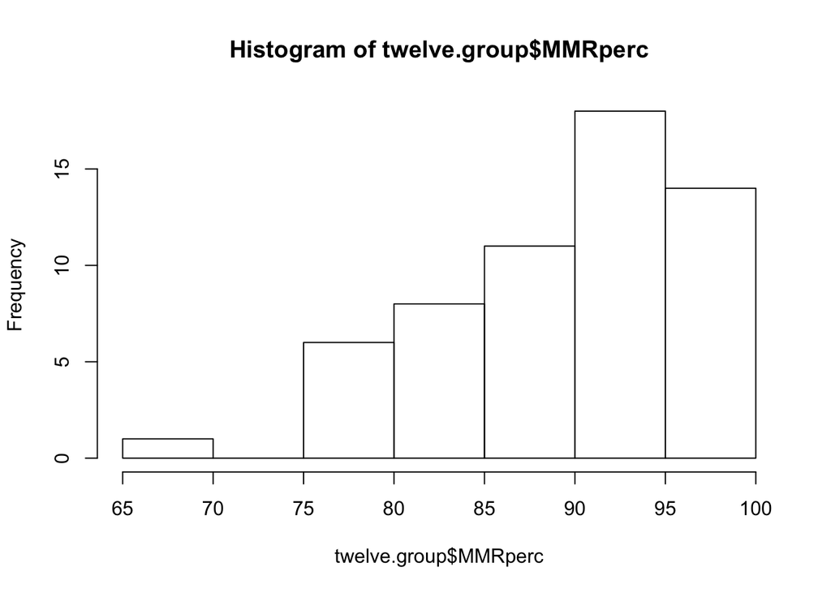

```r
hist(twelve.group$MMRperc)
```

```r
mean(twelve.group$MMRperc, na.rm = TRUE)
```

```
## [1] 89.19492
```

```r
sd(twelve.group$MMRperc, na.rm = TRUE)
```

```
## [1] 6.707685
```

Average kindergarten MMR vaccination coverage for all counties is below the WHO recommended herd immmunity level of 93%

School type was then broken up by public and private to observe whether there was a significant difference in vaccination coverage between public and private schools

A note, previous research and investigations have shown that charter schools are one of the driving forces behind low vaccination rates. Charter schools do not receive a seperate classification under the California Department of Education. Instead, they are classified as public schools in this database as that is what CDE considers them. It was therefore not possible to examine charter schools seperately.

```r
#group by county and public/private
twelve.group2 <- twelve %>% group_by(county, Public.Private) %>%  summarise_at(vars(enrollment:VARIperc), mean, na.rm = TRUE)

twelve.private <- twelve.group2 %>% filter(Public.Private == "PRIVATE")
twelve.public <- twelve.group2 %>% filter(Public.Private == "PUBLIC")

str(twelve.private)
```

```
## Classes 'grouped_df', 'tbl_df', 'tbl' and 'data.frame':  46 obs. of  21 variables:
##  $ county         : Factor w/ 60 levels "","ALAMEDA","ALPINE",..: 2 4 5 6 8 11 12 14 15 16 ...
##  $ Public.Private : Factor w/ 4 levels "","PRIVATE","PUBLIC",..: 2 2 2 2 2 2 2 2 2 2 ...
##  $ enrollment     : num  26 NaN 21 10 27.2 ...
##  $ UTDnum         : num  23.4 NaN 18 10 24.9 ...
##  $ UTDpercent     : num  87.5 NaN 80 100 91 ...
##  $ conditionalnum : num  2.02 NaN 2 0 0.86 ...
##  $ conditionalperc: num  9.57 NaN 13.25 0 3.36 ...
##  $ PMEnum         : num  0.0449 NaN 0 0 0.04 ...
##  $ PMEperc        : num  0.146 NaN 0 0 0.08 ...
##  $ PBEnum         : num  0.618 NaN 1 0 1.46 ...
##  $ PBEperc        : num  2.78 NaN 6.75 0 5.5 ...
##  $ DTPnum         : num  24.3 NaN 18.2 10 25.1 ...
##  $ DTPperc        : num  92.4 NaN 82.5 100 91.9 ...
##  $ Polionum       : num  24.2 NaN 18.1 10 25.1 ...
##  $ Polioperc      : num  91.7 NaN 81.2 100 91.8 ...
##  $ MMRnum         : num  23.9 NaN 18.2 10 25.3 ...
##  $ MMRperc        : num  89.7 NaN 82.5 100 92.8 ...
##  $ HEPBnum        : num  24.9 NaN 18.8 10 25.4 ...
##  $ HEPBperc       : num  94.4 NaN 84.8 100 93.3 ...
##  $ VARInum        : num  25 NaN 19 10 25.5 ...
##  $ VARIperc       : num  95.1 NaN 87.2 100 93.4 ...
##  - attr(*, "vars")= chr "county"
##  - attr(*, "drop")= logi TRUE
##  - attr(*, "indices")=List of 46
##   ..$ : int 0
##   ..$ : int 1
##   ..$ : int 2
##   ..$ : int 3
##   ..$ : int 4
##   ..$ : int 5
##   ..$ : int 6
##   ..$ : int 7
##   ..$ : int 8
##   ..$ : int 9
##   ..$ : int 10
##   ..$ : int 11
##   ..$ : int 12
##   ..$ : int 13
##   ..$ : int 14
```

[output cut: 22 more lines]

```
##   ..$ : int 37
##   ..$ : int 38
##   ..$ : int 39
##   ..$ : int 40
##   ..$ : int 41
##   ..$ : int 42
##   ..$ : int 43
##   ..$ : int 44
##   ..$ : int 45
##  - attr(*, "group_sizes")= int  1 1 1 1 1 1 1 1 1 1 ...
##  - attr(*, "biggest_group_size")= int 1
##  - attr(*, "labels")='data.frame':   46 obs. of  1 variable:
##   ..$ county: Factor w/ 60 levels "","ALAMEDA","ALPINE",..: 2 4 5 6 8 11 12 14 15 16 ...
##   ..- attr(*, "vars")= chr "county"
##   ..- attr(*, "drop")= logi TRUE
```

```r
str(twelve.public)
```

```
## Classes 'grouped_df', 'tbl_df', 'tbl' and 'data.frame':  58 obs. of  21 variables:
##  $ county         : Factor w/ 60 levels "","ALAMEDA","ALPINE",..: 2 3 4 5 6 7 8 10 11 12 ...
##  $ Public.Private : Factor w/ 4 levels "","PRIVATE","PUBLIC",..: 3 3 3 3 3 3 3 3 3 3 ...
##  $ enrollment     : num  80 19 47 59.9 38.5 ...
##  $ UTDnum         : num  69.6 16 42.5 53 29.8 ...
##  $ UTDpercent     : num  85.1 84 90.7 85.9 74.8 ...
##  $ conditionalnum : num  9.16 1 0.833 3.39 4.3 ...
##  $ conditionalperc: num  13.23 5 1.5 6.95 11.6 ...
##  $ PMEnum         : num  0.0708 0 0 0.0976 0.1 ...
##  $ PMEperc        : num  0.0991 0 0 0.1463 0.2 ...
##  $ PBEnum         : num  1.19 2 3.67 3.44 4.3 ...
##  $ PBEperc        : num  1.58 11 7.67 7.02 13.7 ...
##  $ DTPnum         : num  72.2 16 42.7 54.3 30.5 ...
##  $ DTPperc        : num  88.8 84 90.8 88.4 77.4 ...
##  $ Polionum       : num  72.1 16 42.7 54.1 30.7 ...
##  $ Polioperc      : num  88.6 84 90.8 88.3 78.3 ...
##  $ MMRnum         : num  74.1 16 42.5 54 30.8 ...
##  $ MMRperc        : num  91.9 84 90.7 87.8 78.5 ...
##  $ HEPBnum        : num  74.2 16 43.3 55.3 33.3 ...
##  $ HEPBperc       : num  91.7 84 92.3 90.4 84.3 ...
##  $ VARInum        : num  75 16 43.3 55.6 33.4 ...
##  $ VARIperc       : num  93 84 92.3 90.8 84.6 ...
##  - attr(*, "vars")= chr "county"
##  - attr(*, "drop")= logi TRUE
##  - attr(*, "indices")=List of 58
##   ..$ : int 0
##   ..$ : int 1
##   ..$ : int 2
##   ..$ : int 3
##   ..$ : int 4
##   ..$ : int 5
##   ..$ : int 6
##   ..$ : int 7
##   ..$ : int 8
##   ..$ : int 9
##   ..$ : int 10
##   ..$ : int 11
##   ..$ : int 12
##   ..$ : int 13
##   ..$ : int 14
```

[output cut: 34 more lines]

```
##   ..$ : int 49
##   ..$ : int 50
##   ..$ : int 51
##   ..$ : int 52
##   ..$ : int 53
##   ..$ : int 54
##   ..$ : int 55
##   ..$ : int 56
##   ..$ : int 57
##  - attr(*, "group_sizes")= int  1 1 1 1 1 1 1 1 1 1 ...
##  - attr(*, "biggest_group_size")= int 1
##  - attr(*, "labels")='data.frame':   58 obs. of  1 variable:
##   ..$ county: Factor w/ 60 levels "","ALAMEDA","ALPINE",..: 2 3 4 5 6 7 8 10 11 12 ...
##   ..- attr(*, "vars")= chr "county"
##   ..- attr(*, "drop")= logi TRUE
```

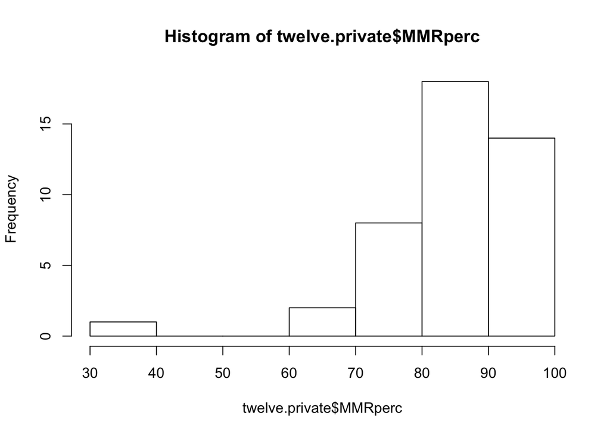

```r
hist(twelve.private$MMRperc)
```

```r
mean(twelve.private$MMRperc, na.rm = TRUE)
```

```
## [1] 84.71465
```

```r
sd(twelve.private$MMRperc, na.rm = TRUE)
```

```
## [1] 10.9477
```

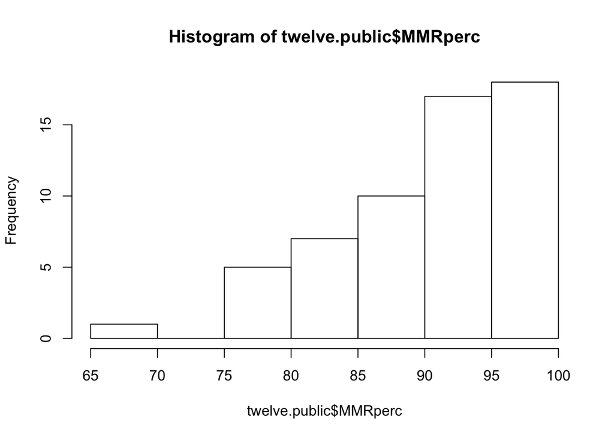

```r
hist(twelve.public$MMRperc)
```

```r
mean(twelve.public$MMRperc, na.rm = TRUE)
```

```
## [1] 89.93994
```

```r
sd(twelve.public$MMRperc, na.rm = TRUE)
```

```
## [1] 6.773881
```

There did not seem to be a huge difference between public and private kindergarten MMR coverage. Boxplots and t-tests were used to test this assumption.

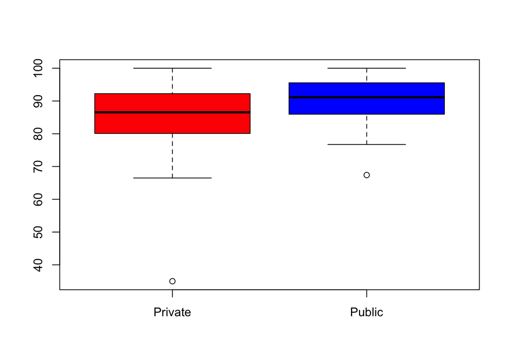

```r
boxplot(twelve.private$MMRperc, twelve.public$MMRperc, names = c("Private", "Public"),
        col = c("red", "blue"))
```

```r
t.test(twelve.private$MMRperc, twelve.public$MMRperc, paired = FALSE, alternative = "two.sided")
```

```
##
##  Welch Two Sample t-test
##
## data:  twelve.private$MMRperc and twelve.public$MMRperc
## t = -2.7623, df = 65.347, p-value = 0.007446
## alternative hypothesis: true difference in means is not equal to 0
## 95 percent confidence interval:
##  -9.002817 -1.447757
## sample estimates:
## mean of x mean of y
##  84.71465  89.93994
```

Average kindergarten vaccination rates were significantly different between public and private schools. Private Schools had lower MMR coverage overall, along with a wider distribution as compared to public schools.

To examine this more thoroughly, maps were made to look at MMR coverage county by county

```r
#drop NaN row
twelve.group <- twelve.group[-c(1), ]

#read in fips codes
fips <- read.csv("fips.csv")
fips$fips.code <- paste0("0", fips$fips.code)

#Add in fips codes
twelve.group$fips <- fips$fips.code

mean(twelve.group$MMRperc, na.rm = TRUE)
```

```
## [1] 89.19492
```

```r
sd(twelve.group$MMRperc, na.rm = TRUE)
```

```
## [1] 6.707685
```

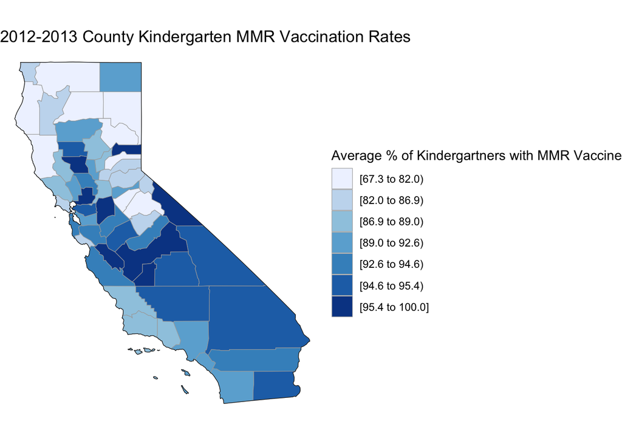

```r
df_county_MMR <- data.frame(region=twelve.group$fips, value=twelve.group$MMRperc)


df_county_MMR$region <- as.numeric(as.character(df_county_MMR$region))

county_choropleth(df_county_MMR, state_zoom="california", title="2012-2013 County Kindergarten MMR Vaccination Rates", legend="Average % of Kindergartners with MMR Vaccine")
```

2016 Data was then examined to look at vaccination coverage post SB 277

```r
#drop unnecessary rows
sixteen <- sixteen[-c(1,2,3,4), ]


#rename variables in sixteen database
sixteen <- dplyr::rename(sixteen, School.Code = X2016.2017.IMMUNIZATION.STATUS.OF.KINDERGARTEN.STUDENTS..CALIFORNIA, county = X, Public.Private = X.1, district = X.2, city = X.3, school.name = X.4, enrollment = X.5, UTDnum = X.6, UTDpercent = X.7, conditionalnum = X.8, conditionalperc = X.9, PMEnum = X.10, PMEperc = X.11, PBEnum = X.12, PBEperc = X.13, Othersnum = X.14, Othersperc = X.15, Overduenum = X.16, Overdueperc = X.17, DTPnum = X.18, DTPperc = X.19, Polionum = X.20, Polioperc = X.21, MMRnum = X.22, MMRperc = X.23, HEBPnum = X.24, HEBPperc = X.25, Varnum = X.26, Varperc = X.27)

#non-numeric symbols were removed
sixteen$MMRperc <- gsub("%","",sixteen$MMRperc)
sixteen$MMRperc <- gsub("≥","",sixteen$MMRperc)

#make numeric
sixteen$MMRperc <- as.numeric(as.character(sixteen$MMRperc))
str(sixteen)
```

```
## 'data.frame':    6935 obs. of  30 variables:
##  $ School.Code    : Factor w/ 6939 levels "","    that the physical condition of the student or medical circumstances relating to the student are such that i"| __truncated__,..: 831 660 1046 1060 697 669 4827 5253 4648 4649 ...
##  $ county         : Factor w/ 59 levels "","2","ALAMEDA",..: 3 3 3 3 3 3 3 3 3 3 ...
##  $ Public.Private : Factor w/ 5 levels "","3","PRIVATE",..: 5 5 5 5 5 5 5 5 5 5 ...
##  $ district       : Factor w/ 788 levels "","4","ABC UNIFIED",..: 7 7 7 7 7 7 8 8 8 8 ...
##  $ city           : Factor w/ 857 levels "","5","ACAMPO",..: 300 514 514 514 514 514 12 12 12 12 ...
##  $ school.name    : Factor w/ 5863 levels "","6","A BETTER CHANCE / CALIFORNIA AUTISM FOUNDATION",..: 57 1063 1131 2800 5394 5849 149 374 1328 1436 ...
##  $ enrollment     : Factor w/ 235 levels "","100","101",..: 6 186 24 205 192 186 29 209 229 202 ...
##  $ UTDnum         : Factor w/ 217 levels "","   .","--*",..: 3 3 22 167 3 3 3 3 207 3 ...
##  $ UTDpercent     : Factor w/ 82 levels "","   .","%",..: 7 6 77 59 6 6 7 6 80 6 ...
##  $ conditionalnum : Factor w/ 43 levels "","   .","--*",..: 3 3 41 13 3 3 3 3 34 3 ...
##  $ conditionalperc: Factor w/ 52 levels "","   .","%",..: 4 5 47 23 5 5 4 5 35 5 ...
##  $ PMEnum         : Factor w/ 23 levels "","   .","--*",..: 3 3 5 5 3 3 3 3 5 3 ...
##  $ PMEperc        : Factor w/ 31 levels "","   .","%",..: 4 5 7 7 5 5 4 5 7 5 ...
##  $ PBEnum         : Factor w/ 33 levels "","   .","--*",..: 3 3 5 5 3 3 3 3 5 3 ...
```

[output cut: 16 more lines]

```r
#group by county
sixteen.group <- sixteen %>% group_by(county) %>%  summarise_at(vars(MMRperc), mean, na.rm = TRUE)

str(sixteen.group)
```

```
## Classes 'tbl_df', 'tbl' and 'data.frame':    57 obs. of  2 variables:
##  $ county : Factor w/ 59 levels "","2","ALAMEDA",..: 1 3 4 5 6 7 8 10 11 12 ...
##  $ MMRperc: num  NaN 96.6 95.5 94.7 88.1 ...
```

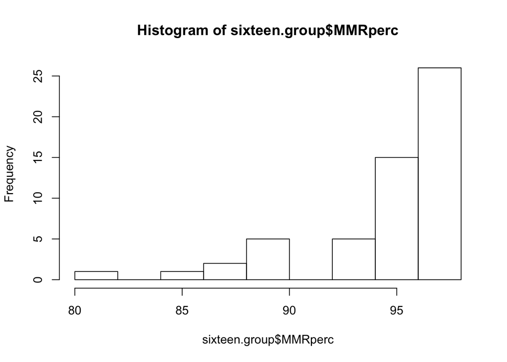

```r
#drop empty row
sixteen.group <- sixteen.group[-c(1), ]

hist(sixteen.group$MMRperc)
```

```r
mean(sixteen.group$MMRperc, na.rm = TRUE)
```

```
## [1] 94.4717
```

```r
sd(sixteen.group$MMRperc, na.rm = TRUE)
```

```
## [1] 3.709824
```

Data was then segmented by public vs. private schools to examine whether there was still a significant difference between them post-legislation change

```r
#group by county and public/private

sixteen.group2 <- sixteen %>% group_by(county, Public.Private) %>%  summarise_at(vars(MMRperc), mean, na.rm = TRUE)

sixteen.private <- sixteen.group2 %>% filter(Public.Private == "PRIVATE")
sixteen.public <- sixteen.group2 %>% filter(Public.Private == "PUBLIC")


str(sixteen.private)
```

```
## Classes 'grouped_df', 'tbl_df', 'tbl' and 'data.frame':  43 obs. of  3 variables:
##  $ county        : Factor w/ 59 levels "","2","ALAMEDA",..: 3 5 6 8 11 12 15 17 19 20 ...
##  $ Public.Private: Factor w/ 5 levels "","3","PRIVATE",..: 3 3 3 3 3 3 3 3 3 3 ...
##  $ MMRperc       : num  94.4 91 NaN 93.2 95 ...
##  - attr(*, "vars")= chr "county"
##  - attr(*, "drop")= logi TRUE
##  - attr(*, "indices")=List of 43
##   ..$ : int 0
##   ..$ : int 1
##   ..$ : int 2
##   ..$ : int 3
##   ..$ : int 4
##   ..$ : int 5
##   ..$ : int 6
##   ..$ : int 7
##   ..$ : int 8
##   ..$ : int 9
##   ..$ : int 10
##   ..$ : int 11
##   ..$ : int 12
##   ..$ : int 13
##   ..$ : int 14
##   ..$ : int 15
##   ..$ : int 16
##   ..$ : int 17
##   ..$ : int 18
##   ..$ : int 19
##   ..$ : int 20
##   ..$ : int 21
##   ..$ : int 22
##   ..$ : int 23
##   ..$ : int 24
##   ..$ : int 25
##   ..$ : int 26
##   ..$ : int 27
##   ..$ : int 28
##   ..$ : int 29
##   ..$ : int 30
##   ..$ : int 31
##   ..$ : int 32
##   ..$ : int 33
##   ..$ : int 34
##   ..$ : int 35
##   ..$ : int 36
##   ..$ : int 37
##   ..$ : int 38
##   ..$ : int 39
##   ..$ : int 40
##   ..$ : int 41
##   ..$ : int 42
##  - attr(*, "group_sizes")= int  1 1 1 1 1 1 1 1 1 1 ...
##  - attr(*, "biggest_group_size")= int 1
##  - attr(*, "labels")='data.frame':   43 obs. of  1 variable:
##   ..$ county: Factor w/ 59 levels "","2","ALAMEDA",..: 3 5 6 8 11 12 15 17 19 20 ...
##   ..- attr(*, "vars")= chr "county"
##   ..- attr(*, "drop")= logi TRUE
```

```r
str(sixteen.public)
```

```
## Classes 'grouped_df', 'tbl_df', 'tbl' and 'data.frame':  56 obs. of  3 variables:
##  $ county        : Factor w/ 59 levels "","2","ALAMEDA",..: 3 4 5 6 7 8 10 11 12 13 ...
##  $ Public.Private: Factor w/ 5 levels "","3","PRIVATE",..: 5 5 5 5 5 5 5 5 5 5 ...
##  $ MMRperc       : num  97.1 95.5 94.9 88.1 97.5 ...
##  - attr(*, "vars")= chr "county"
##  - attr(*, "drop")= logi TRUE
##  - attr(*, "indices")=List of 56
##   ..$ : int 0
##   ..$ : int 1
##   ..$ : int 2
##   ..$ : int 3
##   ..$ : int 4
##   ..$ : int 5
##   ..$ : int 6
##   ..$ : int 7
##   ..$ : int 8
##   ..$ : int 9
##   ..$ : int 10
##   ..$ : int 11
##   ..$ : int 12
##   ..$ : int 13
##   ..$ : int 14
##   ..$ : int 15
##   ..$ : int 16
##   ..$ : int 17
##   ..$ : int 18
##   ..$ : int 19
##   ..$ : int 20
##   ..$ : int 21
##   ..$ : int 22
##   ..$ : int 23
##   ..$ : int 24
##   ..$ : int 25
##   ..$ : int 26
##   ..$ : int 27
##   ..$ : int 28
##   ..$ : int 29
##   ..$ : int 30
##   ..$ : int 31
##   ..$ : int 32
```

[output cut: 14 more lines]

```
##   ..$ : int 47
##   ..$ : int 48
##   ..$ : int 49
##   ..$ : int 50
##   ..$ : int 51
##   ..$ : int 52
##   ..$ : int 53
##   ..$ : int 54
##   ..$ : int 55
##  - attr(*, "group_sizes")= int  1 1 1 1 1 1 1 1 1 1 ...
##  - attr(*, "biggest_group_size")= int 1
##  - attr(*, "labels")='data.frame':   56 obs. of  1 variable:
##   ..$ county: Factor w/ 59 levels "","2","ALAMEDA",..: 3 4 5 6 7 8 10 11 12 13 ...
##   ..- attr(*, "vars")= chr "county"
##   ..- attr(*, "drop")= logi TRUE
```

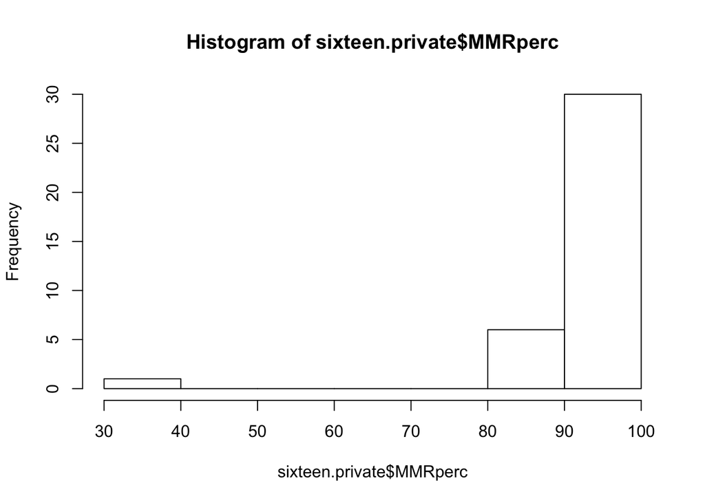

```r
hist(sixteen.private$MMRperc)
```

```r
mean(sixteen.private$MMRperc, na.rm = TRUE)
```

```
## [1] 91.0538
```

```r
sd(sixteen.private$MMRperc, na.rm = TRUE)
```

```
## [1] 9.346561
```

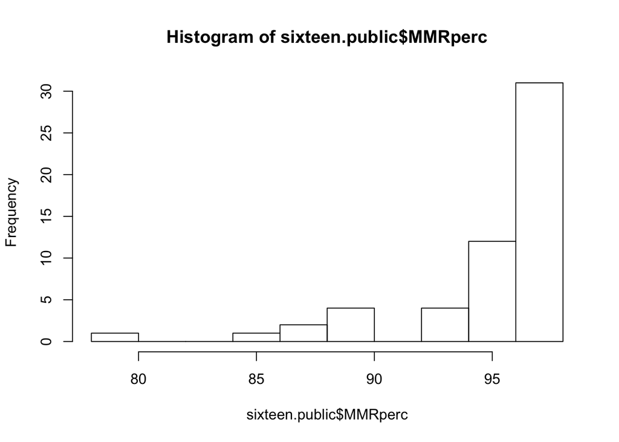

```r
hist(sixteen.public$MMRperc)
```

```r
mean(sixteen.public$MMRperc, na.rm = TRUE)
```

```
## [1] 94.82741
```

```r
sd(sixteen.public$MMRperc, na.rm = TRUE)
```

```
## [1] 3.80648
```

Average Kindergarten MMR coverage no longer seemed to be significantly different between public and private schools. Boxplots and t-tests were executed to test this assumption.

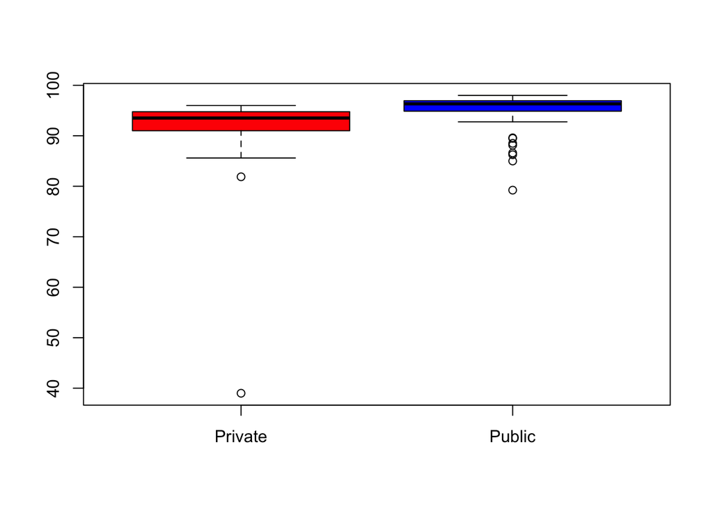

```r
boxplot(sixteen.private$MMRperc, sixteen.public$MMRperc, names = c("Private", "Public"),
        col = c("red", "blue"))
```

```r
t.test(sixteen.private$MMRperc, sixteen.public$MMRperc, paired = FALSE, alternative = "two.sided")
```

```
##
##  Welch Two Sample t-test
##
## data:  sixteen.private$MMRperc and sixteen.public$MMRperc
## t = -2.3294, df = 44.116, p-value = 0.02448
## alternative hypothesis: true difference in means is not equal to 0
## 95 percent confidence interval:
##  -7.0383131 -0.5089139
## sample estimates:
## mean of x mean of y
##  91.05380  94.82741
```

Post SB 277 there public and private schools still had significantly different kindergarten vaccination coverage at the .05 level, but no longer at the .01 level.

2016-2017 data was mapped to view on a county-by-county level the kindergarten MMR coverage

```r
#drop unnecessary rows

#Add in fips codes
#read in fips codes
sixteen.fips <- read.csv("sixteen.fips.csv")
sixteen.fips$fips.code <- paste0("0", sixteen.fips$fips.code)

sixteen.group$fips <- sixteen.fips$fips.code



df_16county_MMR <- data.frame(region=sixteen.group$fips, value=sixteen.group$MMRperc)


df_16county_MMR$region <- as.numeric(as.character(df_16county_MMR$region))

county_choropleth(df_16county_MMR, state_zoom="california", title="2016-2017 County Kindergarten MMR Vaccination Rates", legend="Average % of Kindergartners with MMR Vaccine") + scale_fill_brewer(palette=1)
```

```
## which will replace the existing scale.
```

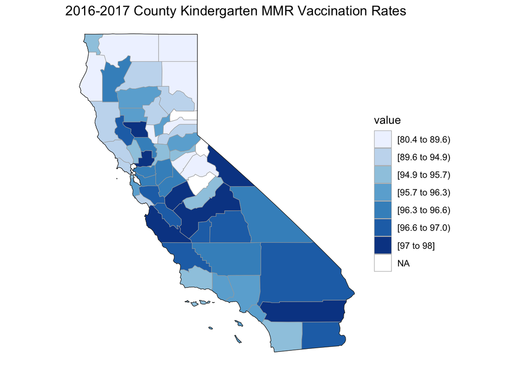

```r
mean(sixteen.group$MMRperc, na.rm = TRUE)
```

```
## [1] 94.4717
```

```r
sd(sixteen.group$MMRperc, na.rm = TRUE)
```

```
## [1] 3.709824
```

Coverage of kindergarten MMR vaccination rates seemed to be much closer to herd immunity level across the state. The northern counties that had had extremely low MMR coverage were now much closer to herd immunity level.

Ultimately, the best measure of effect of SB277 is the change in rates by each county. The ultimate goal of the law was to increase vaccination rates, therefore the difference between 2016-2017 and 2012-2013 was calculated

```r
#12 drop rows without 16 data (Alpine, Sierra, and Mariposa did not report in 2016-2017)
twelve.match <- twelve.group[-c(2, 46), ]


#make change variable
sixteen.group$change <- sixteen.group$MMRperc - twelve.match$MMRperc

mean(sixteen.group$change, na.rm = TRUE)
```

```
## [1] 5.314637
```

```r
sd(sixteen.group$change, na.rm = TRUE)
```

```
## [1] 4.491115
```

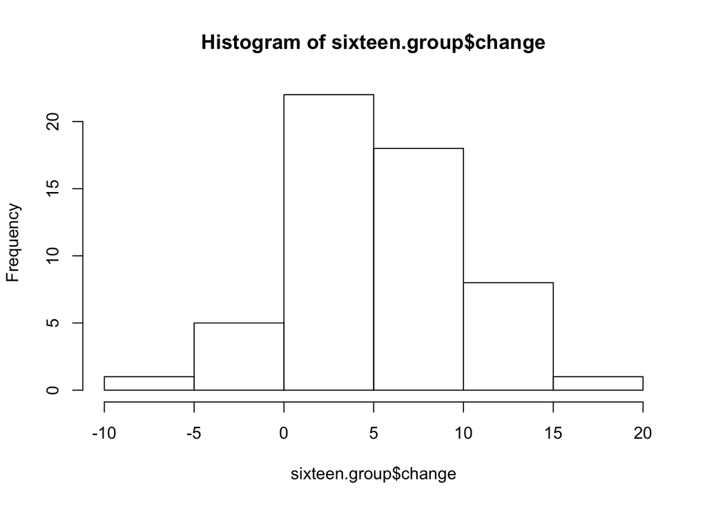

```r
hist(sixteen.group$change)
```

Average change presents as a normal distribution, with some counties reporting positive change and some negative. However, average change among all counties was ~5% – which is excellent for vaccine coverage.

Maps were created to visualize this

```r
change_county_MMR <- data.frame(region=sixteen.group$fips, value=sixteen.group$change)
change_county_MMR$region <- as.numeric(as.character(change_county_MMR$region))

county_choropleth(change_county_MMR, state_zoom="california", title="Change in MMR Coverage 1213 - 1617", legend="Average % Change of Kindergartners with MMR Vaccine") + scale_fill_brewer(palette=3)
```

```
## which will replace the existing scale.
```

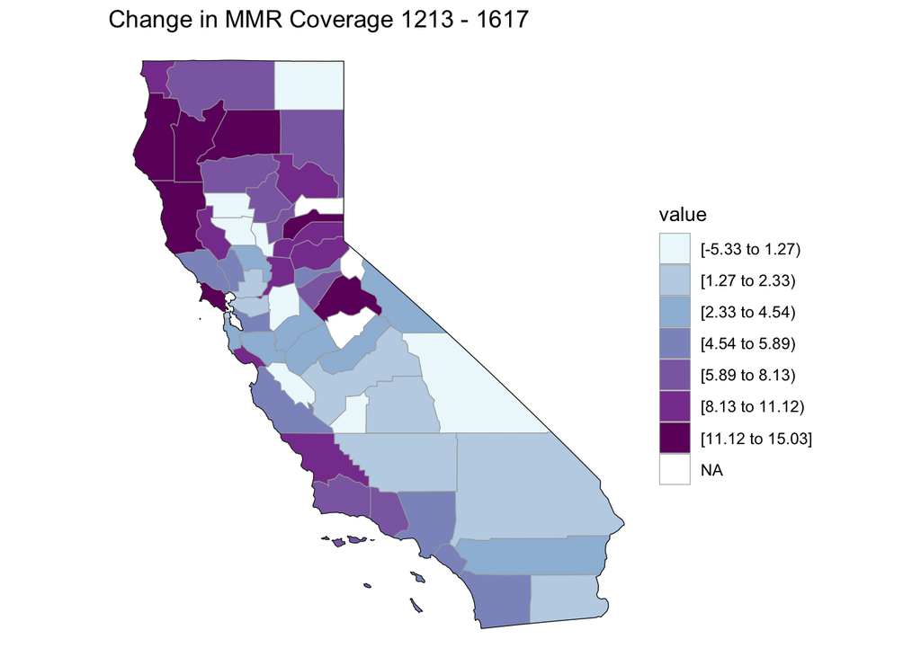

```r
counties <- readRDS(gzcon(url("https://raw.githubusercontent.com/HimesGroup/BMIN503/master/DataFiles/uscounties_2010.rds")))

counties.CA <- filter(counties, STATE == "6")
counties.CA
```

```
## Simple feature collection with 58 features and 6 fields
## geometry type:  MULTIPOLYGON
## dimension:      XY
## bbox:           xmin: -124.4096 ymin: 32.53416 xmax: -114.1315 ymax: 42.00952
## epsg (SRID):    4326
## proj4string:    +proj=longlat +datum=WGS84 +no_defs
## First 10 features:
##            GEO_ID STATE COUNTY       NAME   LSAD CENSUSAREA
## 1  0500000US06005     6    005     Amador County    594.583
## 2  0500000US06021     6    021      Glenn County   1313.947
## 3  0500000US06033     6    033       Lake County   1256.464
## 4  0500000US06043     6    043   Mariposa County   1448.816
## 5  0500000US06055     6    055       Napa County    748.362
## 6  0500000US06089     6    089     Shasta County   3775.402
## 7  0500000US06099     6    099 Stanislaus County   1494.827
## 8  0500000US06115     6    115       Yuba County    631.839
## 9  0500000US06003     6    003     Alpine County    738.332
## 10 0500000US06007     6    007      Butte County   1636.464
##                          geometry
## 1  MULTIPOLYGON (((-120.9955 3...
## 2  MULTIPOLYGON (((-122.9377 3...
## 3  MULTIPOLYGON (((-122.6274 3...
## 4  MULTIPOLYGON (((-120.3877 3...
## 5  MULTIPOLYGON (((-122.1033 3...
## 6  MULTIPOLYGON (((-123.0654 4...
## 7  MULTIPOLYGON (((-120.9314 3...
## 8  MULTIPOLYGON (((-121.3334 3...
## 9  MULTIPOLYGON (((-120.0724 3...
## 10 MULTIPOLYGON (((-121.0767 3...
```

```r
counties.CA$COUNTY <- as.character(counties.CA$COUNTY)
counties.CA$fips.code <- paste(counties.CA$STATE, counties.CA$COUNTY, sep = "")
head(counties$fips.code)
```

```r
counties.CA$fips.code <- as.integer(counties.CA$fips.code)
```

A new dataframe was created to examine this further. T-tests were executed to examine whether 2012-2013 average MMR coverage was significantly lower than 2016-2017 MMR coverage. Boxplots were created to visualize the distribution of MMR coverage across the state of California.

```r
total <- data.frame(twelve.match$county, twelve.match$MMRperc, sixteen.group$MMRperc, sixteen.group$change, sixteen.group$fips)

total <- dplyr::rename(total, fips.code = "sixteen.group.fips", change = "sixteen.group.change", MMR16 = "sixteen.group.MMRperc", MMR12 = "twelve.match.MMRperc", county = "twelve.match.county")

str(total)
```

```
## 'data.frame':    56 obs. of  5 variables:
##  $ county   : Factor w/ 60 levels "","ALAMEDA","ALPINE",..: 2 4 5 6 7 8 10 11 12 13 ...
##  $ MMR12    : num  91.3 90.7 86.9 80.5 98.2 ...
##  $ MMR16    : num  96.6 95.5 94.7 88.1 97.5 ...
##  $ change   : num  5.34 4.83 7.76 7.67 -0.7 ...
##  $ fips.code: Factor w/ 56 levels "06001","06005",..: 1 2 3 4 5 6 7 8 9 10 ...
```

```r
total$fips.code <- as.numeric(as.character(total$fips.code))
counties.total <- inner_join(counties.CA, total, by = "fips.code")

str(counties.total)
```

```
## Classes 'sf' and 'data.frame':   56 obs. of  12 variables:
##  $ GEO_ID    : Factor w/ 3221 levels "0500000US01001",..: 189 197 203 208 214 231 236 244 190 209 ...
##  $ STATE     : chr  "6" "6" "6" "6" ...
##  $ COUNTY    : chr  "005" "021" "033" "043" ...
##  $ NAME      : Factor w/ 1909 levels "Abbeville","Acadia",..: 38 668 956 1071 1198 1561 1620 1904 244 1121 ...
##  $ LSAD      : Factor w/ 8 levels "Borough","CA",..: 4 4 4 4 4 4 4 4 4 4 ...
##  $ CENSUSAREA: num  595 1314 1256 1449 748 ...
##  $ fips.code : num  6005 6021 6033 6043 6055 ...
##  $ county    : Factor w/ 60 levels "","ALAMEDA","ALPINE",..: 4 13 19 24 30 47 52 60 5 25 ...
##  $ MMR12     : num  90.7 95.4 87.6 85.7 90.7 ...
##  $ MMR16     : num  95.5 95.7 96.7 NaN 95.3 ...
##  $ change    : num  4.833 0.286 9.144 NaN 4.536 ...
##  $ geometry  :sfc_MULTIPOLYGON of length 56; first list element: List of 1
##   ..$ :List of 1
##   .. ..$ : num [1:14, 1:2] -121 -121 -121 -121 -121 ...
##   ..- attr(*, "class")= chr  "XY" "MULTIPOLYGON" "sfg"
##  - attr(*, "sf_column")= chr "geometry"
##  - attr(*, "agr")= Factor w/ 3 levels "constant","aggregate",..: NA NA NA NA NA NA NA NA NA NA ...
##   ..- attr(*, "names")= chr  "GEO_ID" "STATE" "COUNTY" "NAME" ...
```

```r
t.test(counties.total$MMR12, counties.total$MMR16, paired = TRUE, alternative = "two.sided")
```

```
##
##  Paired t-test
##
## data:  counties.total$MMR12 and counties.total$MMR16
## t = -8.7761, df = 54, p-value = 5.628e-12
## alternative hypothesis: true difference in means is not equal to 0
## 95 percent confidence interval:
##  -6.528755 -4.100518
## sample estimates:
## mean of the differences
##               -5.314637
```

```r
mean(counties.total$MMR12, na.rm = TRUE)
```

```
## [1] 89.09474
```

```r
sd(counties.total$MMR12, na.rm = TRUE)
```

```
## [1] 6.633667
```

```r
mean(counties.total$MMR16, na.rm = TRUE)
```

```
## [1] 94.4717
```

```r
sd(counties.total$MMR12, na.rm = TRUE)
```

```
## [1] 6.633667
```

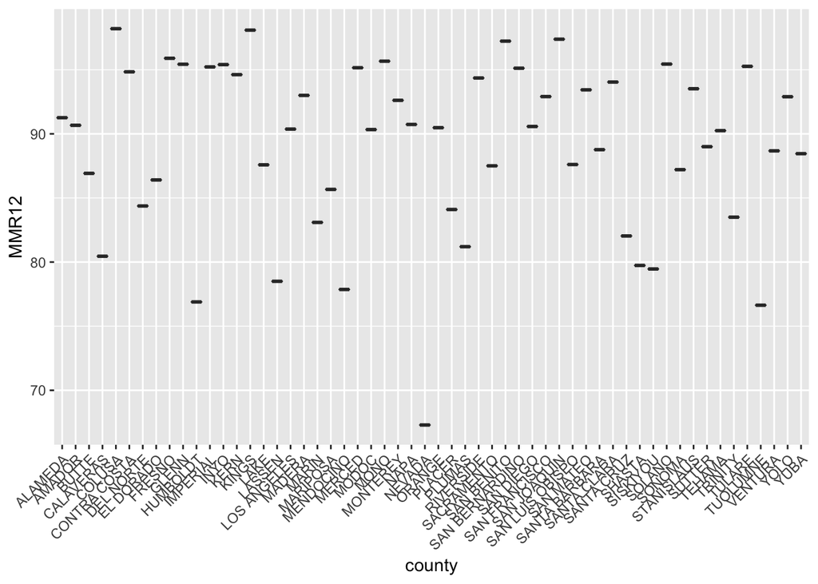

```r
ggplot(data = counties.total, aes(x = county, y = MMR12)) + geom_boxplot() + theme(axis.text.x=element_text(angle=45, hjust=1))
```

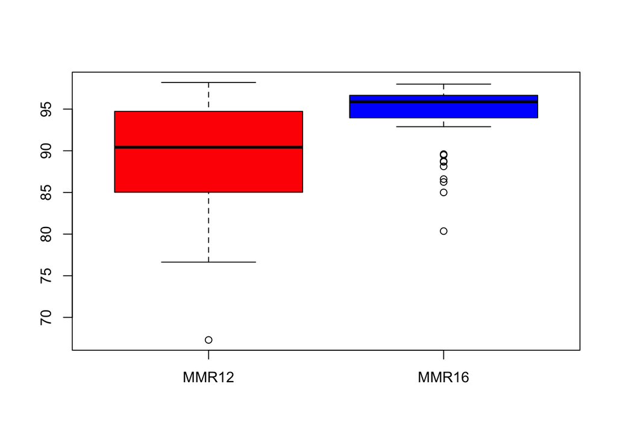

```r
boxplot(counties.total$MMR12, counties.total$MMR16, data = counties.total, names = c("MMR12", "MMR16"),
        col = c("red", "blue"))
```

A paired samples t-test showed 2016-2017 kindergarten MMR coverage was significantly higher than that from 2012-2013. Additionally, boxplots showed that the distribution of coverage narrowed, with the IQR of coverage all above the WHO’s herd immunity level.

Additional maps were made to visualize this.

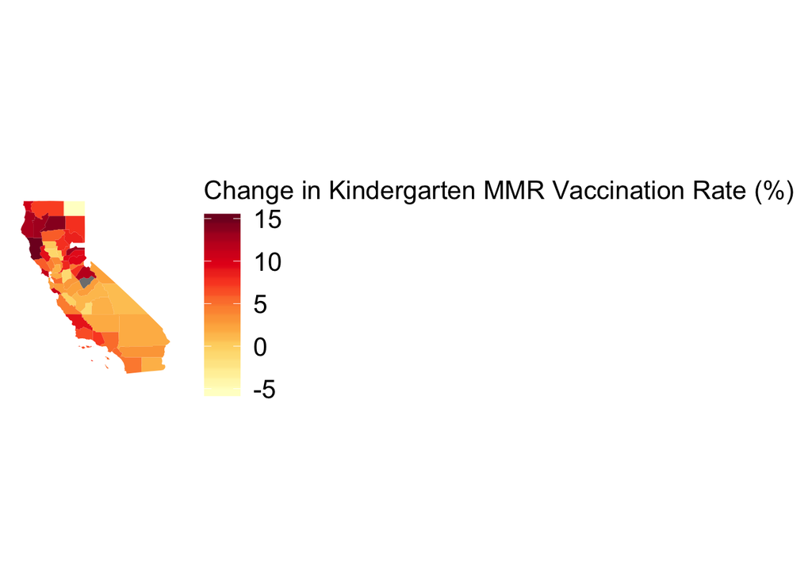

```r
change_min <- min(counties.total$change, na.rm = TRUE)
change_max <- max(counties.total$change, na.rm = TRUE)


my_theme <- function() {
  theme_minimal() +
  theme(axis.line = element_blank(),
        axis.text = element_blank(),
        axis.title = element_blank(),
        panel.grid = element_line(color = "white"),
        legend.key.size = unit(0.8, "cm"),
        legend.text = element_text(size = 16),
        legend.title = element_text(size = 16),
        plot.title = element_text(size = 22))
}

myPalette <- colorRampPalette(brewer.pal(9, "YlOrRd"))

# Map change in rate
ggplot() +
  geom_sf(data = counties.total, aes(fill = change), lwd = 0) +
  my_theme()+
  scale_fill_gradientn(name = "Change in Kindergarten MMR Vaccination Rate (%)", colours = myPalette(100),
                       limit = range(change_min, change_max))
```

```r
pal_fun <- colorBin(palette = brewer.pal(9, "RdBu")[c(1:5, 7)],
                    bins = c(-3, -1, 1, 5, 9, 13, 17), reverse = TRUE,
                    NULL)


# Pop-up message
pu_message <- paste0(counties.total$county,
                     "<br>Change in K MMR rate (2012-2016): ",
                     round(counties.total$change, 1), "%")

# Basic leaflet map
leaflet(counties.total) %>%
  addPolygons(fillColor = ~pal_fun(change),
              popup = pu_message) %>%
  addTiles()
```

[interactive chart not shown]

```r
# Adding more customization
leaflet(counties.total) %>%
  addPolygons(stroke = FALSE,
              fillColor = ~pal_fun(change),
              fillOpacity = 0.5, smoothFactor = 0.5,
              popup = pu_message) %>%
  addLegend("bottomright",
            pal=pal_fun,
            values=~change,
            title = 'Change in Kinder MMR Coverage (2012-2016)',
            opacity = 1) %>%
  addScaleBar()
```

[interactive chart not shown]

Finally, county-level median income was brought in and mapped to examine the spread throughout the state of California.

```r
income <- read.csv("2015Income.csv")
income$Median.Income <- gsub(",","",income$Median.Income)
income$Median.Income <- gsub("\\$","",income$Median.Income)

income$Median.Income <- as.numeric(as.character(income$Median.Income))

str(income)
```

```
## 'data.frame':    58 obs. of  7 variables:
##  $ Rank            : int  1 2 3 4 5 6 7 8 9 10 ...
##  $ County          : Factor w/ 58 levels "Alameda","Alpine",..: 21 41 43 38 7 31 1 9 28 48 ...
##  $ Returns         : Factor w/ 58 levels "1,083","1,396,551",..: 6 28 54 35 37 11 47 48 44 15 ...
##  $ AGI             : Factor w/ 58 levels "$1,081,947,000 ",..: 27 47 12 51 40 15 52 48 43 10 ...
##  $ Median.Income   : num  63110 59192 57281 56722 50667 ...
##  $ Taxable.Assessed: Factor w/ 58 levels "$1,224,918,000 ",..: 5 34 53 35 17 48 25 27 29 37 ...
##  $ Population      : Factor w/ 58 levels "1,116,882","1,157",..: 24 50 5 52 1 35 4 16 10 36 ...
```

```r
income <- dplyr::rename(income, county = "County")

income.fips <- inner_join(fips, income, by = "county")

str(income.fips)
```

```
## 'data.frame':    58 obs. of  8 variables:
##  $ fips.code       : chr  "06001" "06003" "06005" "06007" ...
##  $ county          : Factor w/ 58 levels "Alameda","Alpine",..: 1 2 3 4 5 6 7 8 9 10 ...
##  $ Rank            : int  7 13 20 40 22 32 5 44 8 53 ...
##  $ Returns         : Factor w/ 58 levels "1,083","1,396,551",..: 47 26 8 53 13 56 37 51 48 29 ...
##  $ AGI             : Factor w/ 58 levels "$1,081,947,000 ",..: 52 26 55 37 1 50 40 35 48 19 ...
##  $ Median.Income   : num  50031 40869 39090 32261 38936 ...
##  $ Taxable.Assessed: Factor w/ 58 levels "$1,224,918,000 ",..: 25 58 26 16 36 28 17 8 27 49 ...
##  $ Population      : Factor w/ 58 levels "1,116,882","1,157",..: 4 2 34 23 39 22 1 26 16 57 ...
```

```r
income_county <- data.frame(region=income.fips$fips.code, value=income.fips$Median.Income)

income_county$region <- as.numeric(as.character(income_county$region))

str(income_county)
```

```
## 'data.frame':    58 obs. of  2 variables:
##  $ region: num  6001 6003 6005 6007 6009 ...
##  $ value : num  50031 40869 39090 32261 38936 ...
```

```r
county_choropleth(income_county, state_zoom="california", title="Medican Income", legend="Income by County") + scale_fill_brewer(palette=2)
```

```
## which will replace the existing scale.
```

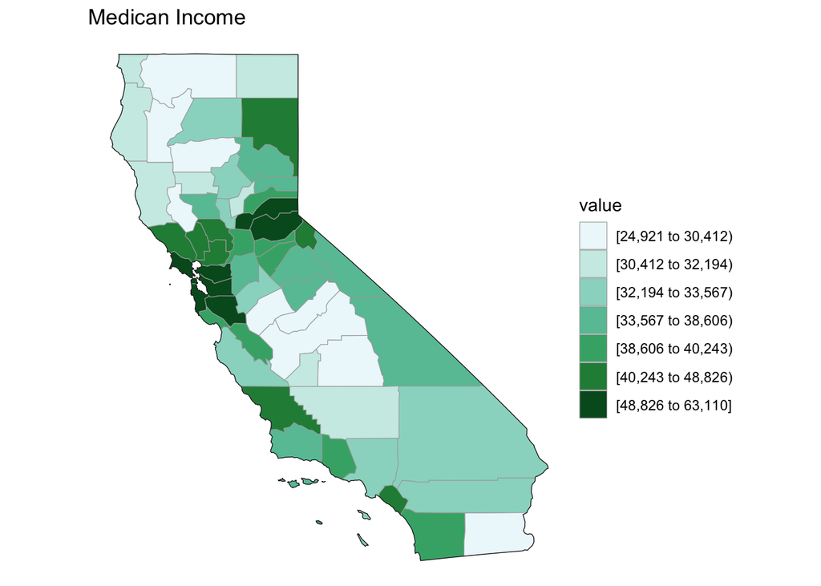

```r
#12 drop rows without 16 data
income.match <- income[-c(27, 13), ]

income.fips$fips.code <- as.numeric(as.character(income.fips$fips.code))

str(income.fips)
```

```
## 'data.frame':    58 obs. of  8 variables:
##  $ fips.code       : num  6001 6003 6005 6007 6009 ...
##  $ county          : Factor w/ 58 levels "Alameda","Alpine",..: 1 2 3 4 5 6 7 8 9 10 ...
##  $ Rank            : int  7 13 20 40 22 32 5 44 8 53 ...
##  $ Returns         : Factor w/ 58 levels "1,083","1,396,551",..: 47 26 8 53 13 56 37 51 48 29 ...
##  $ AGI             : Factor w/ 58 levels "$1,081,947,000 ",..: 52 26 55 37 1 50 40 35 48 19 ...
##  $ Median.Income   : num  50031 40869 39090 32261 38936 ...
##  $ Taxable.Assessed: Factor w/ 58 levels "$1,224,918,000 ",..: 25 58 26 16 36 28 17 8 27 49 ...
##  $ Population      : Factor w/ 58 levels "1,116,882","1,157",..: 4 2 34 23 39 22 1 26 16 57 ...
```

```r
MMR.income <- inner_join(income.fips, counties.total, by = "fips.code")

str(MMR.income)
```

```
## 'data.frame':    56 obs. of  19 variables:
##  $ fips.code       : num  6001 6005 6007 6009 6011 ...
##  $ county.x        : Factor w/ 58 levels "Alameda","Alpine",..: 1 3 4 5 6 7 8 9 10 11 ...
##  $ Rank            : int  7 20 40 22 32 5 44 8 53 43 ...
##  $ Returns         : Factor w/ 58 levels "1,083","1,396,551",..: 47 8 53 13 56 37 51 48 29 4 ...
##  $ AGI             : Factor w/ 58 levels "$1,081,947,000 ",..: 52 55 37 1 50 40 35 48 19 46 ...
##  $ Median.Income   : num  50031 39090 32261 38936 33799 ...
##  $ Taxable.Assessed: Factor w/ 58 levels "$1,224,918,000 ",..: 25 26 16 36 28 17 8 27 49 19 ...
##  $ Population      : Factor w/ 58 levels "1,116,882","1,157",..: 4 34 23 39 22 1 26 16 57 29 ...
##  $ GEO_ID          : Factor w/ 3221 levels "0500000US01001",..: 187 189 190 191 192 193 194 195 196 197 ...
##  $ STATE           : chr  "6" "6" "6" "6" ...
##  $ COUNTY          : chr  "001" "005" "007" "009" ...
##  $ NAME            : Factor w/ 1909 levels "Abbeville","Acadia",..: 17 38 244 252 402 410 487 558 625 668 ...
##  $ LSAD            : Factor w/ 8 levels "Borough","CA",..: 4 4 4 4 4 4 4 4 4 4 ...
##  $ CENSUSAREA      : num  739 595 1636 1020 1151 ...
##  $ county.y        : Factor w/ 60 levels "","ALAMEDA","ALPINE",..: 2 4 5 6 7 8 10 11 12 13 ...
##  $ MMR12           : num  91.3 90.7 86.9 80.5 98.2 ...
##  $ MMR16           : num  96.6 95.5 94.7 88.1 97.5 ...
##  $ change          : num  5.34 4.83 7.76 7.67 -0.7 ...
##  $ geometry        :sfc_MULTIPOLYGON of length 56; first list element: List of 1
##   ..$ :List of 1
##   .. ..$ : num [1:70, 1:2] -122 -122 -122 -122 -122 ...
##   ..- attr(*, "class")= chr  "XY" "MULTIPOLYGON" "sfg"
```

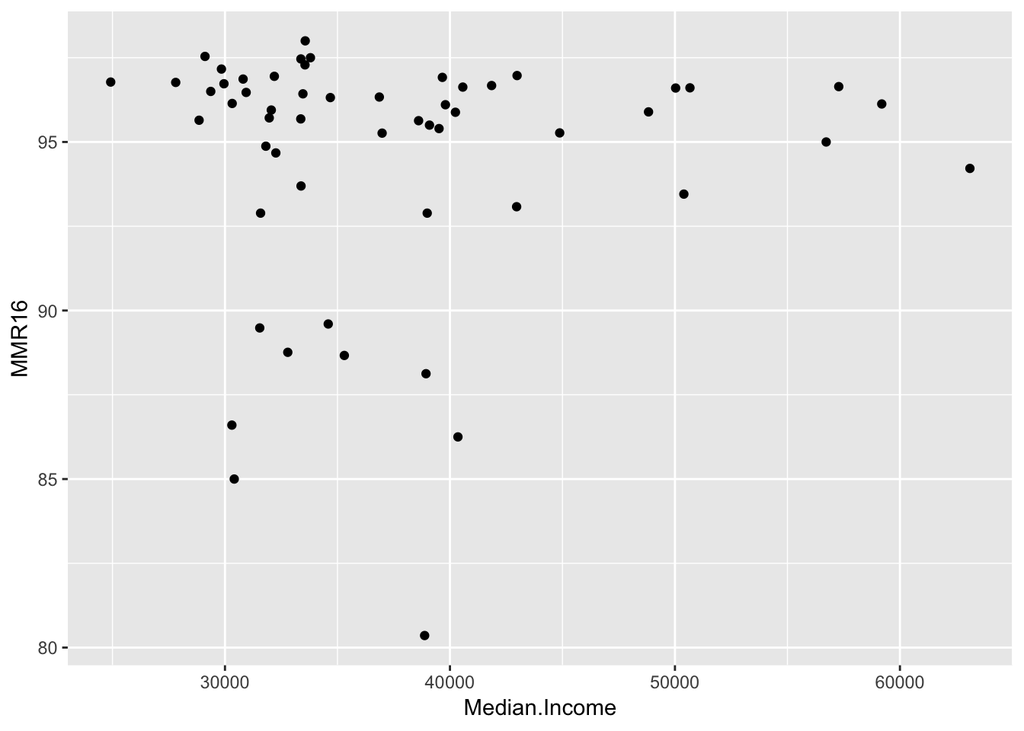

```r
ggplot(data=MMR.income, aes(Median.Income, MMR16)) +
    geom_point()
```

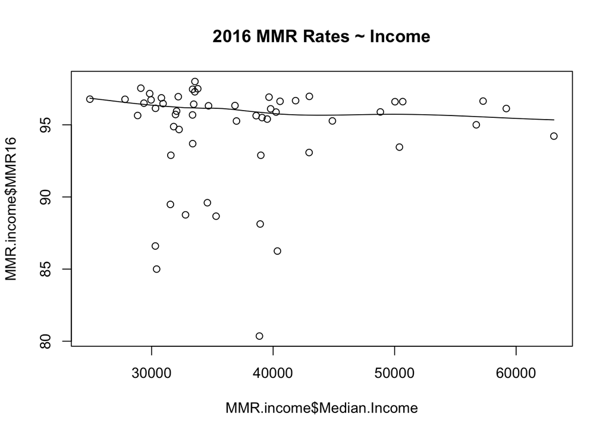

```r
scatter.smooth(x=MMR.income$Median.Income, y=MMR.income$MMR16, main="2016 MMR Rates ~ Income")
```

```r
regress <- lm(MMR16 ~ Median.Income, data = MMR.income)
summary(regress)
```

```
##
## Call:
## lm(formula = MMR16 ~ Median.Income, data = MMR.income)
##
## Residuals:
##     Min      1Q  Median      3Q     Max
## -14.138  -0.708   1.343   2.150   3.600
##
## Coefficients:
##                Estimate Std. Error t value Pr(>|t|)
## (Intercept)   9.380e+01  2.309e+00  40.629   <2e-16 ***
## Median.Income 1.789e-05  5.999e-05   0.298    0.767
## ---
## Signif. codes:  0 '***' 0.001 '**' 0.01 '*' 0.05 '.' 0.1 ' ' 1
##
## Residual standard error: 3.742 on 53 degrees of freedom
##   (1 observation deleted due to missingness)
## Multiple R-squared:  0.001676,   Adjusted R-squared:  -0.01716
## F-statistic: 0.08896 on 1 and 53 DF,  p-value: 0.7667
```

# Conclusion

Passage of SB 277 significantly raised county-level kindergarten MMR vaccination coverage. County level MMR rates were closer to herd immunity post SB 277, indicating that overall the legislation was successful. Additionally, the difference between public and private MMR rates was still significantly different at alpha = 0.05, it was no longer significant at alpha = 0.01, indicating that this difference may also be narrowing. Change in MMR vaccination overall was positive. While some counties had a decrase in kindergarten MMR coverage, the counties that had the lowest coverage in 2012-2013 all had a net positive gain in coverage in 2016-2017.

There are limitations to this research. Firstly, all data is self-reported by the school to the State of California. School funding depends on the number of children in school that day, disentivizing the school from excluding children based on their vaccination status. Therefore, it is possible schools are thereby disentivized from reporting their true vaccination rate so they do not have to exclude children. Additionally, public schools in California are cutting services and positions to save money. Therefore, the job of verifying vaccination records often falls to school secretaries, health clerks, or over-worked school nurses. There are many ways in which error could be introduced in this process.

Because this study was looking at averages across the county, Moran’s i measures of spatial autocorrelation was not an appropriate statistical test to use. California has especially large counties, and using a latitude and longitude measurement of the county would not appropriately convey the spatial relationship to the next county. Future research should examine the individual school level MMR coverage, and spatial autocorrelation would be an appropriate test to use there.

Finally, results of this study are limited to the state of California. Comparable, population-based, datasets are not publically available for other states. While the CDC does collect an estimate of vaccination coverage across all states, they use a random-sampling study framework that participants must elect to join. In contrast, the California dataset is as close to possible of an estimate of every single enrolled kindergartner in the state of California. Kindergarten is not a required grade, but the dataframe does represent every single public and private school kindergarten within the state. Further research can compare these numbers to CDC National Immunization Survey data to see if they are similar.

These analyses serve as evidence of the efficacy of SB 277. Other states can use SB 277 legislation as a model when looking to raise their kindergaten MMR vaccination rates.

```